# Normalization and Integration

2024-07-23

## Load data

```r
obj
```

```
An object of class Seurat
33694 features across 31021 samples within 1 assay
Active assay: RNA (33694 features, 0 variable features)
 2 layers present: counts, data
```

## Basic QC

We now filter cells with more than 1000 features.

```r
obj <- subset(obj, nFeature_RNA > 1000)
obj
```

```
An object of class Seurat
33694 features across 10434 samples within 1 assay
Active assay: RNA (33694 features, 0 variable features)
 2 layers present: counts, data
```

The object contains data from nine different batches (stored in the Method column in the object metadata), representing seven different technologies. We can see them:

```r
table(obj$Method)
```

```
  10x Chromium (v2) 10x Chromium (v2) A 10x Chromium (v2) B   10x Chromium (v3)            CEL-Seq2            Drop-seq             inDrops
               2172                 844                 831                2866                 504                1810                 545
           Seq-Well          Smart-seq2
                350                 512
```

## Normalization

The first step after the QC is normalization, to make gene expression comparable between cells.

As we have multiple batches, we have first to split the object RNA layer into them, and then perform the normalization.

```r
obj[["RNA"]] <- split(obj[["RNA"]], f = obj$Method)
obj
```

```
An object of class Seurat
33694 features across 10434 samples within 1 assay
Active assay: RNA (33694 features, 0 variable features)
 18 layers present: counts.Smart-seq2, counts.CEL-Seq2, counts.10x_Chromium_v2_A, counts.10x_Chromium_v2_B, counts.10x_Chromium_v3, counts.Drop-seq, counts.Seq-Well, counts.inDrops, counts.10x_Chromium_v2, data.Smart-seq2, data.CEL-Seq2, data.10x_Chromium_v2_A, data.10x_Chromium_v2_B, data.10x_Chrom…
```

We can now perform the normalization for each batch with just one line of code:

```r
obj <- NormalizeData(obj)
```

```
Normalizing layer: counts.Smart-seq2
Normalizing layer: counts.CEL-Seq2
Normalizing layer: counts.10x_Chromium_v2_A
Normalizing layer: counts.10x_Chromium_v2_B
Normalizing layer: counts.10x_Chromium_v3
Normalizing layer: counts.Drop-seq
Normalizing layer: counts.Seq-Well
Normalizing layer: counts.inDrops
Normalizing layer: counts.10x_Chromium_v2
```

```r
obj
```

```
An object of class Seurat
33694 features across 10434 samples within 1 assay
Active assay: RNA (33694 features, 0 variable features)
 18 layers present: counts.Smart-seq2, counts.CEL-Seq2, counts.10x_Chromium_v2_A, counts.10x_Chromium_v2_B, counts.10x_Chromium_v3, counts.Drop-seq, counts.Seq-Well, counts.inDrops, counts.10x_Chromium_v2, data.Smart-seq2, data.CEL-Seq2, data.10x_Chromium_v2_A, data.10x_Chromium_v2_B, data.10x_Chrom…
```

This normalization set a scale factor of 10,000 for each cell (so the sum of the counts of a cell is set to 10,000), and adjust the expression value of each gene accordingly. It then calculate the log1p of those values (natural logarithm of the value+1 to account for zeros).

We can confirm that normalization has made the cells expression comparable:

```r
apply(obj[["RNA"]]$counts.10x_Chromium_v2[, 1:10], MARGIN = 2, FUN = function(x) {sum(x)})
```

```
pbmc2_10X_V2_AAACCTGAGATGGGTC pbmc2_10X_V2_AAACCTGAGCTAGGCA pbmc2_10X_V2_AAACCTGAGGGTCTCC pbmc2_10X_V2_AAACCTGGTCCGAACC pbmc2_10X_V2_AAACCTGTCTTGTACT
                         2360                          3456                          3802                          3826                          5801
pbmc2_10X_V2_AAACGGGCATTATCTC pbmc2_10X_V2_AAACGGGGTCCAACTA pbmc2_10X_V2_AAAGATGCAGCTGCAC pbmc2_10X_V2_AAAGATGCATCTACGA pbmc2_10X_V2_AAAGATGGTCCTCCAT
                         2189                          7973                          3214                          3382                          2793
```

```r
apply(obj[["RNA"]]$data.10x_Chromium_v2[, 1:10], MARGIN = 2, FUN = function(x) {sum(exp(x) - 1)})
```

```
pbmc2_10X_V2_AAACCTGAGATGGGTC pbmc2_10X_V2_AAACCTGAGCTAGGCA pbmc2_10X_V2_AAACCTGAGGGTCTCC pbmc2_10X_V2_AAACCTGGTCCGAACC pbmc2_10X_V2_AAACCTGTCTTGTACT
                        10000                         10000                         10000                         10000                         10000
pbmc2_10X_V2_AAACGGGCATTATCTC pbmc2_10X_V2_AAACGGGGTCCAACTA pbmc2_10X_V2_AAAGATGCAGCTGCAC pbmc2_10X_V2_AAAGATGCATCTACGA pbmc2_10X_V2_AAAGATGGTCCTCCAT
                        10000                         10000                         10000                         10000                         10000
```

## Dimensionality reduction

In order to run the PCA, we have to perform two operations on the data:

- Extrapolate variable features
- Scale data for those features: when performing PCA, input data should be scaled so that each feature has the same “weight”

```r
head(VariableFeatures(obj), 10)
```

```
 [1] "LYZ"      "S100A9"   "CD74"     "CST3"     "HLA-DRA"  "HLA-DRB1" "GNLY"     "HLA-DPB1" "IGLC3"    "IGKC"
```

```r
obj <- ScaleData(obj)
obj
```

```
An object of class Seurat
33694 features across 10434 samples within 1 assay
Active assay: RNA (33694 features, 2000 variable features)
 19 layers present: counts.Smart-seq2, counts.CEL-Seq2, counts.10x_Chromium_v2_A, counts.10x_Chromium_v2_B, counts.10x_Chromium_v3, counts.Drop-seq, counts.Seq-Well, counts.inDrops, counts.10x_Chromium_v2, data.Smart-seq2, data.CEL-Seq2, data.10x_Chromium_v2_A, data.10x_Chromium_v2_B, data.10x_Chrom…
```

### PCA

```r
obj <- RunPCA(obj)
```

```
PC_ 1
Positive:  LYZ, FCN1, CST3, S100A9, SERPINA1, CTSS, VCAN, CD68, AIF1, PSAP
       S100A8, LST1, GRN, SPI1, CLEC7A, FCER1G, NCF2, CSTA, TYROBP, TYMP
       CD14, FGL2, CSF3R, MPEG1, CPVL, COTL1, MS4A6A, CFD, HCK, MAFB
Negative:  IL32, MALAT1, TRBC2, CD3D, TRAC, CCL5, TRBC1, IL7R, RPS18, CTSW
       CST7, CD247, CD3G, CD2, LDHB, GZMA, SYNE2, RORA, LTB, NKG7
       CD69, SPOCK2, CD7, ITM2A, LYAR, RPS8, GIMAP7, PRF1, CD8A, CXCR4
PC_ 2
Positive:  NKG7, S100A4, SRGN, IL32, CST7, CCL5, ANXA1, CTSW, GZMA, GZMH
       FGFBP2, PRF1, ITGB2, GNLY, CD247, ID2, CD3D, KLRD1, ARL4C, GZMB
       GAPDH, PFN1, CD7, S100A6, CD8A, LYAR, CD3G, RORA, TRBC1, HOPX
Negative:  MS4A1, CD79A, BANK1, IGHM, HLA-DQA1, CD79B, HLA-DQB1, IGKC, LINC00926, HLA-DRA
       CD74, CD22, IGHD, VPREB3, TNFRSF13C, MEF2C, IGHG1, RALGPS2, HLA-DMB, HLA-DPA1
       BLK, HLA-DPB1, JCHAIN, ADAM28, HLA-DRB1, FAM129C, P2RX5, FCRL1, CD24, IGLC2
PC_ 3
Positive:  IL7R, RPLP1, RPS8, RPS18, LTB, MAL, LEF1, RCAN3, LDHB, EEF1A1
       CCR7, RPS2, JUNB, NOSIP, CAMK4, PIK3IP1, TCF7, RPLP0, VIM, TRAC
       TRABD2A, NELL2, TRAT1, RGCC, AQP3, ZFP36L2, INPP4B, RGS10, CD40LG, CD27
Negative:  PRF1, NKG7, GZMB, FGFBP2, KLRD1, GNLY, FCGR3A, CST7, GZMH, KLRF1
       SPON2, GZMA, ADGRG1, CTSW, MYOM2, CCL4, S1PR5, CLIC3, CCL5, HOPX
       TTC38, TRDC, IL2RB, PRSS23, CX3CR1, FCRL6, SH2D1B, IFITM2, ITGB2, PTGDR
PC_ 4
Positive:  MTRNR2L12, MTRNR2L1, GPM6A, KCNJ3, AP000769.1, XIST, MGST2, SLFN5, OAS2, GIMAP7
       GIMAP4, FYB, LINC00861, IL7R, IKZF2, OAS3, SAMHD1, CX3CR1, LBH, SPN
       GBP5, MYOM2, MTRNR2L8, CASP8AP2, SELL, NCL, FOXP1, TCF7, SYNE2, MLLT6
Negative:  RPS2, RPS4Y1, RPLP1, FTH1, RPS18, TMSB10, LY6E, MALAT1, FTL, SUB1
       GAPDH, LGALS1, HERPUD1, JUNB, SNX3, SEC61B, S100A4, S100A6, C12orf75, HLA-DPB1
       RPS8, H1FX, PPP1R14B, DDIT4, HLA-DRB1, HLA-DPA1, MAP3K8, S100A10, MT2A, PRELID1
PC_ 5
Positive:  NFKBIA, CXCL8, TNFAIP3, THBS1, EGR1, NR4A2, SLC2A3, G0S2, IER3, IL1B
       VCAN, DUSP1, MTRNR2L8, CXCR4, SGK1, PTGS2, RPS4Y1, FOSB, BHLHE40, CD83
       DDX3Y, MTRNR2L12, JUN, CYP1B1, KLF6, HIF1A, CD14, KLF10, ZFP36, MT-CO1
Negative:  TMSB4X, CDKN1C, CSF1R, FCGR3A, LINC01272, MS4A7, CKB, HES4, CSTB, RHOC
       AIF1, LST1, TMSB10, LRRC25, FAM110A, XIST, GIMAP7, GIMAP4, PYCARD, RPS2
       ABI3, BATF3, RPS18, TCF7L2, RNASET2, CORO1A, SIGLEC10, ARPC1B, LYPD2, ZNF703
```

```r
obj
```

```
An object of class Seurat
33694 features across 10434 samples within 1 assay
Active assay: RNA (33694 features, 2000 variable features)
 19 layers present: counts.Smart-seq2, counts.CEL-Seq2, counts.10x_Chromium_v2_A, counts.10x_Chromium_v2_B, counts.10x_Chromium_v3, counts.Drop-seq, counts.Seq-Well, counts.inDrops, counts.10x_Chromium_v2, data.Smart-seq2, data.CEL-Seq2, data.10x_Chromium_v2_A, data.10x_Chromium_v2_B, data.10x_Chrom…
 1 dimensional reduction calculated: pca
```

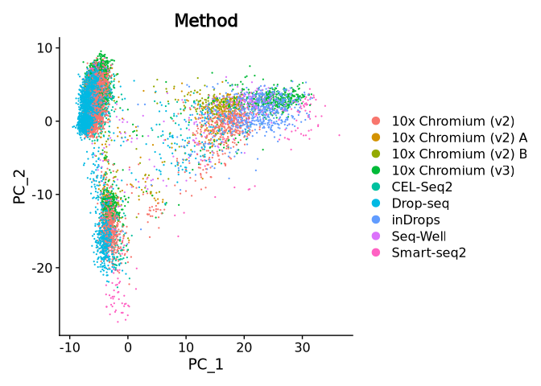

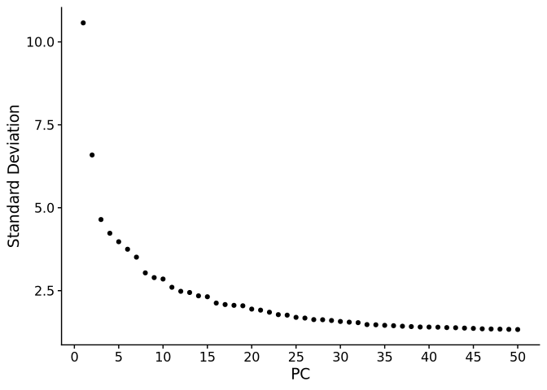

### UMAP

To better highlight differences in the sample, we can visualize the data with the UMAP.

```r
obj <- RunUMAP(obj, dims = 1:16, reduction = "pca", reduction.name = "umap.unintegrated")
```

```
Using method 'umap'
```

```r
obj
```

```
An object of class Seurat
33694 features across 10434 samples within 1 assay
Active assay: RNA (33694 features, 2000 variable features)
 19 layers present: counts.Smart-seq2, counts.CEL-Seq2, counts.10x_Chromium_v2_A, counts.10x_Chromium_v2_B, counts.10x_Chromium_v3, counts.Drop-seq, counts.Seq-Well, counts.inDrops, counts.10x_Chromium_v2, data.Smart-seq2, data.CEL-Seq2, data.10x_Chromium_v2_A, data.10x_Chromium_v2_B, data.10x_Chrom…
 2 dimensional reductions calculated: pca, umap.unintegrated
```

We can now visualize it:

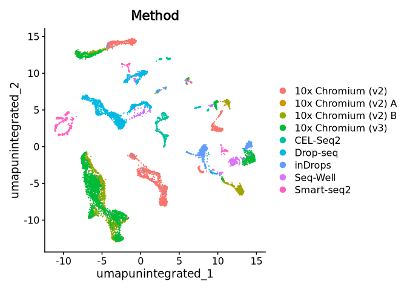

We can see that they clusterize by Method. This data should be integrated, as in scRNA seq experiment the clusters should be celltypes.

## Integration

To perform the integration of the data, we will use the `IntegrateLayers` funtion whithin Seurat. There are different integration methods: CCA, RPCA, Harmony, FastMNN and scVI. We will show CCA and Harmony.

### CCA

```r
obj <- IntegrateLayers(
  object = obj, method = CCAIntegration,
  orig.reduction = "pca", new.reduction = "integrated.cca",
  verbose = FALSE
)
```

[output not shown]

```r
obj <- RunUMAP(obj, dims = 1:16, reduction = "integrated.cca", reduction.name = "umap.cca")
```

```
Using method 'umap'
```

```r
obj
```

```
An object of class Seurat
33694 features across 10434 samples within 1 assay
Active assay: RNA (33694 features, 2000 variable features)
 19 layers present: counts.Smart-seq2, counts.CEL-Seq2, counts.10x_Chromium_v2_A, counts.10x_Chromium_v2_B, counts.10x_Chromium_v3, counts.Drop-seq, counts.Seq-Well, counts.inDrops, counts.10x_Chromium_v2, data.Smart-seq2, data.CEL-Seq2, data.10x_Chromium_v2_A, data.10x_Chromium_v2_B, data.10x_Chrom…
 4 dimensional reductions calculated: pca, umap.unintegrated, integrated.cca, umap.cca
```

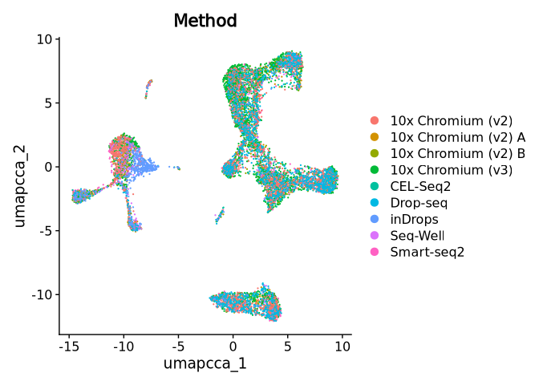

### Harmony

```r
obj <- IntegrateLayers(
  object = obj, method = HarmonyIntegration,
  orig.reduction = "pca", new.reduction = "integrated.harmony",
  verbose = FALSE
)
```

```r
obj <- RunUMAP(obj, dims = 1:16, reduction = "integrated.harmony", reduction.name = "umap.harmony")
```

```
Using method 'umap'
```

```r
obj
```

```
An object of class Seurat
33694 features across 10434 samples within 1 assay
Active assay: RNA (33694 features, 2000 variable features)
 19 layers present: counts.Smart-seq2, counts.CEL-Seq2, counts.10x_Chromium_v2_A, counts.10x_Chromium_v2_B, counts.10x_Chromium_v3, counts.Drop-seq, counts.Seq-Well, counts.inDrops, counts.10x_Chromium_v2, data.Smart-seq2, data.CEL-Seq2, data.10x_Chromium_v2_A, data.10x_Chromium_v2_B, data.10x_Chrom…
 6 dimensional reductions calculated: pca, umap.unintegrated, integrated.cca, umap.cca, integrated.harmony, umap.harmony
```

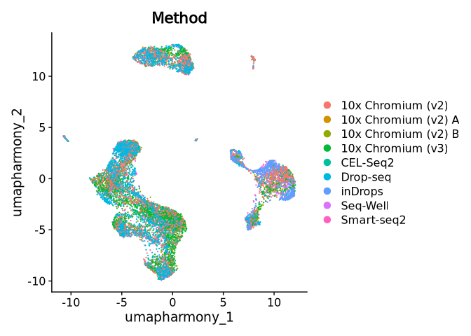

## Extra: SCTNormalization

There is also another normalization method in Seurat, which is an upgraded version of NormalizeData: `SCTransform`. It will replace NormalizeData, FindVariableFeatures and ScaleData functions. It will introduce a new assay: SCT.

```r
obj <- SCTransform(obj, vst.flavor = "v2")
```

[output not shown]

[output cut: 91 more lines]

[output not shown]

```r
obj
```

```
An object of class Seurat
54553 features across 10434 samples within 2 assays
Active assay: SCT (20859 features, 3000 variable features)
 3 layers present: counts, data, scale.data
 1 other assay present: RNA
 6 dimensional reductions calculated: pca, umap.unintegrated, integrated.cca, umap.cca, integrated.harmony, umap.harmony
```